# Lab 4: Robust Regression

Monday, February 1, 2016

## CRAN Task Views

When you want to try something new in R and you're looking for resources, the [CRAN Task Views](http://cran.r-project.org/web/views/) can be a good place to start.

The **Robust** task view offers short descriptions of many applicable packages.

Tonight we'll use `MASS:rlm` (robust linear model), and `quantreg::rq` (quantile regression).

## Looking back: distributions and definitions

OLS, ordinary least-squares, is all about averages, or *expected values*.

- we predict the expected value of \(y\) for given \(X\)
- the coefficient of a single x is the average change in y for a unit change in x

It's a happy coincidence that the computationally easy problem of minimizing the sum of the squared error corresponds to the maximum likelihood estimate for \(E(y)\) *when we assume a Gaussian distribution of errors*.

## Sensitivity to Outliers

But we know averages are relatively sensitive to outliers. We can see that in action (really, in estimation) when we **square** the error, which gives large errors a big effect.

Two common ways to make regression models "robust" to outliers are to address these two issues:

- *quantile regression*, where we predict, e.g., the median instead of the mean
- *M-estimators*, where we change the *loss function* that is **m**inimized

We will do a little theory on the latter, but demonstrate both.

## Four loss functions:

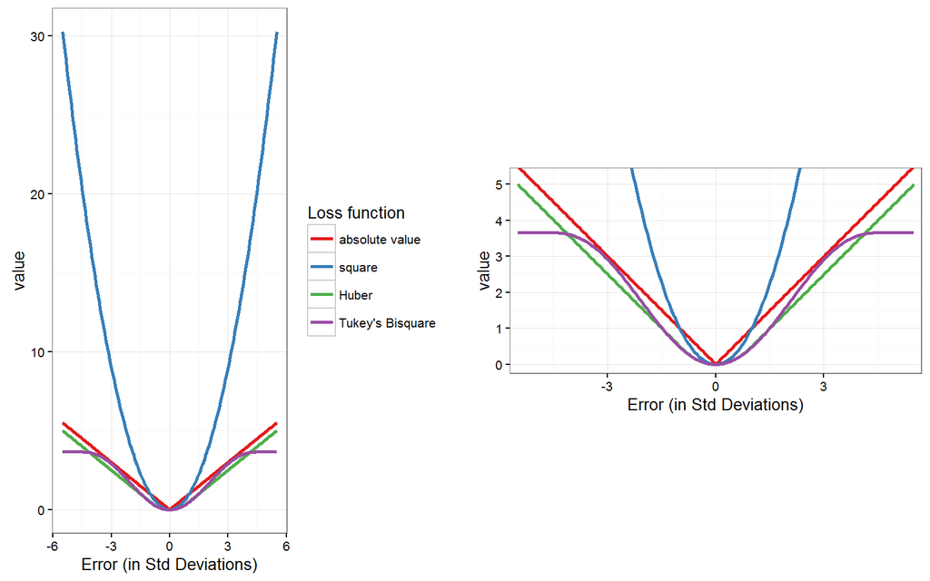

```r
grid.arrange(loss1, loss2, ncol = 2)
```

I include the left plot to emphasize how quickly \(x^2\) gets big as \(x\) gets away from 0.

- Absolute value loss is almost never used in practice. (A discontinuous derivative is trouble for optimization routines.)
- Huber's loss function is similar to absolute, but smoothes out the sharp corner.
- Tukey's bi-square function is similar to Huber/Absolute up to a point, but it flattens out and at some number of standard deviations away from the mean (typically `k = 4.685`).

## Efficiency

Statisticians talk about the efficiency of estimators, by which they mean *how efficiently they use the information in the data*. OLS is provably the most efficient estimator of the normal MLE, so it is considered 100% efficient. Robust estimators can lose efficiency, but the default values of \(k\) for the Huber and Tukey loss functions are chosen so that, asymptotically, they have 95% efficiency.

Internally, these loss functions are transformed and applied as weights to the data points in the regression.

If your data has measurement error recorded for each point, i.e., you have data on the individual errors, using the inverse measurement error as a weight is standard practice. In this case, you can just use the `weights` argument of `lm`.

## Examples

## Phone data

This is classic data for robust regression. It's in the `MASS` package, but as a list rather than a data.frame.

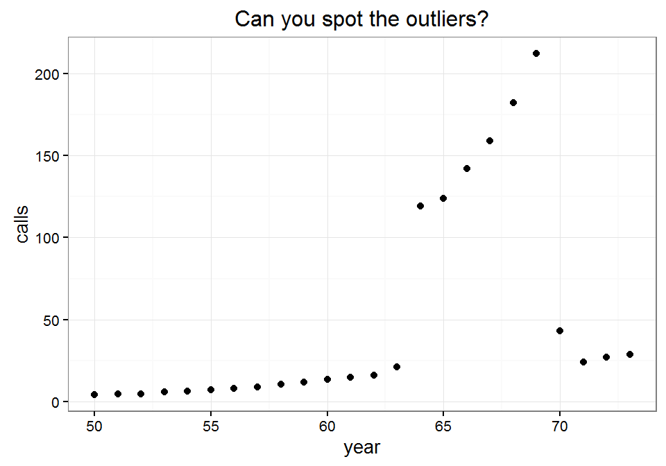

```r
phones = as.data.frame(phones)
ggplot(phones, aes(x = year, y = calls)) + geom_point() +
    labs(title = "Can you spot the outliers?")
```

## `MASS::rlm`

A really nice feature of `rlm` is that it returns a regular `lm` object, with three extra pieces: `s`, the robust scale estimate, `w`, the weights, and `psi` (\(\psi\)) the loss function used.

By default, `rlm` uses `method = "M"`. It works well for outliers in the response, but can still be senstitive to outliers in \(X\). With `method = "MM"`, a more careful estimation is done, adding steps to better estimate the variance. For large `n`, the `"MM"` method can be slow.

```r
mod.lm = lm(calls ~ year, data = phones)
mod.tuk = rlm(calls ~ year, data = phones, method = "MM")
# MM uses Tukey's bisquare
mod.hub = rlm(calls ~ year, data = phones, method = "M", maxit = 500)
# this failed to converge without upping the max iterations
```

```r
display(mod.lm)
```

```
## lm(formula = calls ~ year, data = phones)
##             coef.est coef.se
## (Intercept) -260.06   102.61
## year           5.04     1.66
## ---
## n = 24, k = 2
## residual sd = 56.22, R-Squared = 0.30
```

```r
summary(mod.tuk)
```

```
##
## Call: rlm(formula = calls ~ year, data = phones, method = "MM")
## Residuals:
##      Min       1Q   Median       3Q      Max
##  -1.7442  -0.4543   0.2148  39.0082 188.4577
##
## Coefficients:
##             Value    Std. Error t value
## (Intercept) -52.4230   2.9159   -17.9783
## year          1.1009   0.0471    23.3669
##
## Residual standard error: 2.129 on 22 degrees of freedom
```

```r
summary(mod.hub)
```

```
##
## Call: rlm(formula = calls ~ year, data = phones, maxit = 500, method = "M")
## Residuals:
##     Min      1Q  Median      3Q     Max
## -18.314  -5.953  -1.681  26.460 173.769
##
## Coefficients:
##             Value     Std. Error t value
## (Intercept) -102.6222   26.6082    -3.8568
## year           2.0414    0.4299     4.7480
##
## Residual standard error: 9.032 on 22 degrees of freedom
```

```r
mod_list = list(LM = mod.lm, Tukey = mod.tuk, Huber = mod.hub)
phones_aug = lapply(mod_list, augment) %>%
    bind_rows(.id = "model")
```

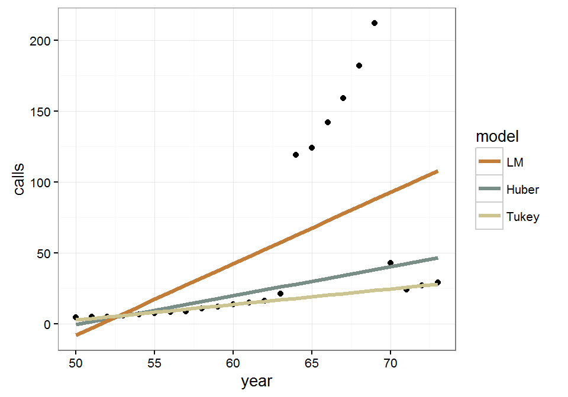

```r
ggplot(phones_aug, aes(x = year, y = calls))+
    geom_point() +
    geom_line(aes(y = .fitted, color = model), size = 1.2) +
    scale_color_manual(values = wes_palette(
        "Moonrise2", n = 3, type = "discrete"
    ), breaks = c("LM", "Huber", "Tukey")
    )
```

```r
library(quantreg)
mod.quant = rq(calls ~ year, data = phones)
phones_aug =
    augment(mod.quant) %>%
    mutate(model = "Quantile") %>%
    bind_rows(phones_aug)
```

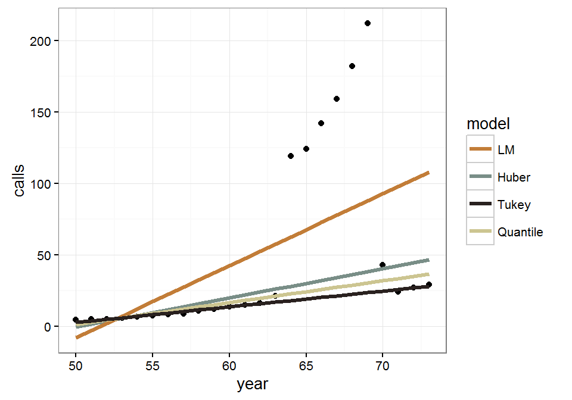

```r
ggplot(phones_aug, aes(x = year, y = calls))+
    geom_point() +
    geom_line(aes(y = .fitted, color = model), size = 1.2) +
    scale_color_manual(values = wes_palette(
        "Moonrise2", n = 4, type = "discrete"
    ),
    breaks = c("LM", "Huber", "Tukey", "Quantile")
    )
```

## Additional resources:

I've lightly covered much of what's in John Fox's [Appendix on Robust Regression](http://cran.r-project.org/doc/contrib/Fox-Companion/appendix-robust-regression.pdf), but if you want more details on what was covered tonight, it's a good and short read.

For a longer (but still not a full book), more theoretical coverage, Bellio and Ventura's [An Introduction to Robust Estimation with R Functions](http://www.dst.unive.it/rsr/BelVenTutorial.pdf) is very readable.

For quantile regression, the `quantreg` package has a [very nice vignette](http://cran.r-project.org/web/packages/quantreg/vignettes/rq.pdf).

## Appendix: `tlm`

```r
library(hett)
mod.tdist = tlm(calls ~ year, data = phones)
# no predict method :(
# we'll have to matrix multiply to get predictions:
phones$tdist.pred = cbind(1, phones$year) %*% coef(mod.tdist$loc.fit)
```